# Statistical Inference Course Project

Bernardo Najlis

October 24, 2015

# Introduction

In this project we will investigate the exponential distribution in R and compare it with the Central Limit Theorem. The exponential distribution can be simulated in R with rexp(n, lambda) where lambda is the rate parameter. The mean of exponential distribution is 1/lambda and the standard deviation is also 1/lambda. We will set lambda = 0.2 for all of the simulations. Also, we will investigate the distribution of averages of 40 exponentials over a thousand simulations.

# Simulations

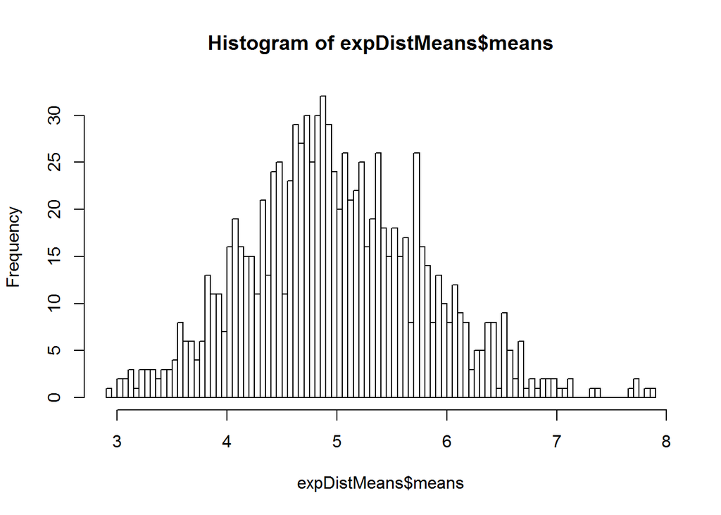

```r
lambda <- 0.2
n <- 40
numberOfSims <- 1000

set.seed(0) #for reproducibility

expDists <- matrix(data=rexp(n*numberOfSims, lambda), nrow = numberOfSims)
expDistMeans <- data.frame(means=apply(expDists, 1, mean))

hist(expDistMeans$means, breaks=100)
```

# Sample and theoretical mean

The expected mean *mu* of an exponential distribution of rate *lambda* is:

*mu* = 1 / *lambda*

```r
mu <- 1/lambda
mu
```

```
## [1] 5
```

Then we can calculate the average of sample means for the simulations as

```r
meanOfMeans <- mean(expDistMeans$means)
meanOfMeans
```

```
## [1] 4.989678
```

Conclusion: the mean of means converges to the expected mean for a large number of samples (1000).

# Sample and Theoretical variance

The expected standard deviation *sigma* of an exponential distribution rate *lambda* is

*sigma* = (1 / *lambda) / sqrt(n)

```r
sigma <- (1/lambda) / sqrt(n)
sigma
```

```
## [1] 0.7905694
```

The variance *var* of the standard deviation *sigma* is

*var* = *sigma* ^ 2

```r
var <- sigma ^ 2
var
```

```
## [1] 0.625
```

For the simulations, let *var_x* be the variance of the average sample mean of the 1,000 simulations of 40 randomly sampled exponential distributions and *sigma_x* its standard deviation.

```r
sigma_x <- sd(expDistMeans$means)
sigma_x
```

```
## [1] 0.8147837
```

```r
var_x <- var(expDistMeans$means)
var_x
```

```
## [1] 0.6638725
```

Conclusion: the numbers are close to each other and should get closer if the number of simulations further increases.

# Distribution and approximation to normal

The following chart shows the histogram of samples overlayed with a normal distribution with calculated values and the theoretical normal distribution. The theoretical an calculated distributions have a high degree of overlapping, allowing us to use the calculated one as a good approximation as the Central Limit Theorem states.

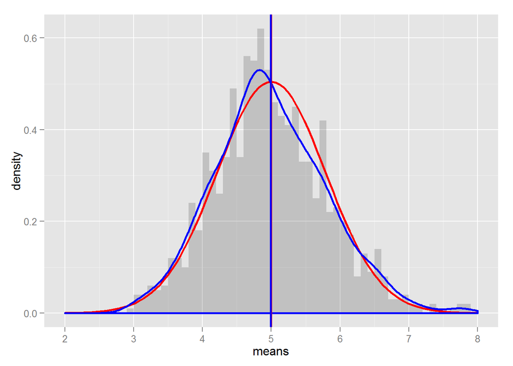

```r
library(ggplot2)  #for plotting graphs
ggplot(data = expDistMeans, aes(x = means)) +
  geom_histogram(binwidth=0.1, aes(y=..density..), alpha=0.2) +
  stat_function(fun = dnorm, arg = list(mean = mu , sd = sigma), colour = "red", size=1) +
  geom_density(colour="blue", size=1) +
  scale_x_continuous(breaks=seq(mu-3,mu+3,1), limits=c(mu-3,mu+3)) +
  geom_vline(xintercept = mu, size=1, colour="red") +
  geom_vline(xintercept = meanOfMeans, size=1, colour="blue")
```